### Project Motivation:

we will use this data set to assist financial institutions make informed decisions regarding loan approvals and deciding weather a customer has good or bad cedit risks by analyzing customers’ payment behavior, as well as all their relevant attributes such as age, income, loan amount, employment status, etc. By utilizing this data, predictive models can be built to forecast customers’ creditworthiness and may be used as a tool for risk assessment and decision-making.

### source

The dataset was sourced from the kaggle website in this URL: https://www.kaggle.com/datasets/ppb00x/credit-risk-customers

## Attribute description

[output not shown]

## Summary of the dataset

```r
setwd("C:/Users/jory0/OneDrive/Desktop/mining project")
```

```r
dataset <- read.csv("credit_customers.csv")
```

```r
nrow(dataset)
```

```
## [1] 1000
```

The output is 1000, which is the number of rows

```r
 ncol(dataset)
```

```
## [1] 21
```

The output is 21 , which is the number of columns

```r
 summary(dataset)
```

```
##  checking_status       duration    credit_history       purpose
##  Length:1000        Min.   : 4.0   Length:1000        Length:1000
##  Class :character   1st Qu.:12.0   Class :character   Class :character
##  Mode  :character   Median :18.0   Mode  :character   Mode  :character
##                     Mean   :20.9
##                     3rd Qu.:24.0
##                     Max.   :72.0
##  credit_amount   savings_status      employment        installment_commitment
##  Min.   :  250   Length:1000        Length:1000        Min.   :1.000
##  1st Qu.: 1366   Class :character   Class :character   1st Qu.:2.000
##  Median : 2320   Mode  :character   Mode  :character   Median :3.000
##  Mean   : 3271                                         Mean   :2.973
##  3rd Qu.: 3972                                         3rd Qu.:4.000
##  Max.   :18424                                         Max.   :4.000
##  personal_status    other_parties      residence_since property_magnitude
##  Length:1000        Length:1000        Min.   :1.000   Length:1000
##  Class :character   Class :character   1st Qu.:2.000   Class :character
##  Mode  :character   Mode  :character   Median :3.000   Mode  :character
##                                        Mean   :2.845
##                                        3rd Qu.:4.000
##                                        Max.   :4.000
##       age        other_payment_plans   housing          existing_credits
##  Min.   :19.00   Length:1000         Length:1000        Min.   :1.000
##  1st Qu.:27.00   Class :character    Class :character   1st Qu.:1.000
##  Median :33.00   Mode  :character    Mode  :character   Median :1.000
##  Mean   :35.55                                          Mean   :1.407
##  3rd Qu.:42.00                                          3rd Qu.:2.000
##  Max.   :75.00                                          Max.   :4.000
##      job            num_dependents  own_telephone      foreign_worker
##  Length:1000        Min.   :1.000   Length:1000        Length:1000
##  Class :character   1st Qu.:1.000   Class :character   Class :character
##  Mode  :character   Median :1.000   Mode  :character   Mode  :character
##                     Mean   :1.155
##                     3rd Qu.:1.000
##                     Max.   :2.000
##     class
##  Length:1000
##  Class :character
##  Mode  :character
##
##
##
```

```r
var_duration <- var(dataset$duration)
```

```r
var_age <- var(dataset$age)
```

```r
var_amount <- var(dataset$credit_amount)
```

## chi square

```r
tbl = table(dataset$class, dataset$purpose)
tbl
```

```
##
##        business domestic appliance education furniture/equipment new car other
##   bad        34                  4        22                  58      89     5
##   good       63                  8        28                 123     145     7
##
##        radio/tv repairs retraining used car
##   bad        62       8          1       17
##   good      218      14          8       86
```

```r
chisq.test(tbl)
```

```
##
##  Pearson's Chi-squared test
##
## data:  tbl
## X-squared = 33.356, df = 9, p-value = 0.0001157
```

```r
tbl = table(dataset$class, dataset$personal_status)
tbl
```

```
##
##        female div/dep/mar male div/sep male mar/wid male single
##   bad                 109           20           25         146
##   good                201           30           67         402
```

```r
chisq.test(tbl)
```

```
##
##  Pearson's Chi-squared test
##
## data:  tbl
## X-squared = 9.6052, df = 3, p-value = 0.02224
```

```r
tbl = table(dataset$class, dataset$other_parties)
tbl
```

```
##
##        co applicant guarantor none
##   bad            18        10  272
##   good           23        42  635
```

```r
chisq.test(tbl)
```

```
##
##  Pearson's Chi-squared test
##
## data:  tbl
## X-squared = 6.6454, df = 2, p-value = 0.03606
```

```r
tbl = table(dataset$class, dataset$property_magnitude)
tbl
```

```
##
##        car life insurance no known property real estate
##   bad  102             71                67          60
##   good 230            161                87         222
```

```r
chisq.test(tbl)
```

```
##
##  Pearson's Chi-squared test
##
## data:  tbl
## X-squared = 23.72, df = 3, p-value = 2.858e-05
```

```r
tbl = table(dataset$class, dataset$housing)
tbl
```

```
##
##        for free own rent
##   bad        44 186   70
##   good       64 527  109
```

```r
chisq.test(tbl)
```

```
##
##  Pearson's Chi-squared test
##
## data:  tbl
## X-squared = 18.2, df = 2, p-value = 0.0001117
```

```r
tbl = table(dataset$class, dataset$job)
tbl
```

```
##
##        high qualif/self emp/mgmt skilled unemp/unskilled non res
##   bad                         51     186                       7
##   good                        97     444                      15
##
##        unskilled resident
##   bad                  56
##   good                144
```

```r
chisq.test(tbl)
```

```
##
##  Pearson's Chi-squared test
##
## data:  tbl
## X-squared = 1.8852, df = 3, p-value = 0.5966
```

```r
tbl = table(dataset$class, dataset$job)
tbl
```

```
##
##        high qualif/self emp/mgmt skilled unemp/unskilled non res
##   bad                         51     186                       7
##   good                        97     444                      15
##
##        unskilled resident
##   bad                  56
##   good                144
```

```r
chisq.test(tbl)
```

```
##
##  Pearson's Chi-squared test
##
## data:  tbl
## X-squared = 1.8852, df = 3, p-value = 0.5966
```

```r
tbl = table(dataset$class, dataset$own_telephone)
tbl
```

```
##
##        none yes
##   bad   187 113
##   good  409 291
```

```r
chisq.test(tbl)
```

```
##
##  Pearson's Chi-squared test with Yates' continuity correction
##
## data:  tbl
## X-squared = 1.1726, df = 1, p-value = 0.2789
```

```r
tbl = table(dataset$class, dataset$other_payment_plans)
tbl
```

```
##
##        bank none stores
##   bad    57  224     19
##   good   82  590     28
```

```r
chisq.test(tbl)
```

```
##
##  Pearson's Chi-squared test
##
## data:  tbl
## X-squared = 12.839, df = 2, p-value = 0.001629
```

## Outliers

```r
library(outliers)
```

```r
OutAge <- outlier(dataset$age, logical = TRUE)
OutDuration <- outlier(dataset$duration, logical = TRUE)
Outamount <- outlier(dataset$credit_amount, logical = TRUE)
```

We created a variable “OutAge” , “OutDuration” to store the result of finding the outliers in the dataset , logical true which specifies the outliers with true .

```r
sum(OutAge)
```

```
## [1] 2
```

```r
sum(OutDuration)
```

```
## [1] 1
```

```r
sum(Outamount)
```

```
## [1] 1
```

```r
Find_outlierAge <- which(OutAge == TRUE, arr.ind = TRUE)
Find_outlierDuration <- which(OutDuration == TRUE, arr.ind = TRUE)
Find_outlierAmount <- which(Outamount == TRUE, arr.ind = TRUE)
```

To find the row nummbers with the Outliers

```r
dataset <- dataset[-Find_outlierAge ,-Find_outlierDuration , ]
dataset <- dataset[-Find_outlierAmount ,]
```

Finally we removed the outliers , out dataset after remvoing the outliers have 996 objects.

## Data Conversion (Encoding categorical data)/discretization

```r
dataset$checking_status <- factor(dataset$checking_status, levels = c("<0", "0<=X<200", "no checking"), labels = c(1, 2, 3))
```

```r
dataset$class <- factor(dataset$class, levels = c("bad", "good"), labels = c(0, 1))
```

```r
dataset$housing = factor(dataset$housing,levels = c("own","for free", "rent"), labels = c(1, 2, 3))
```

```r
dataset$foreign_worker <- factor(dataset$foreign_worker, levels = c("yes", "no"), labels = c(0, 1))
```

Print the final preprocessed dataset

```r
print(dataset)
```

```
##      checking_status duration                 credit_history
## 1                  1        6 critical/other existing credit
## 2                  2       48                  existing paid
## 3                  3       12 critical/other existing credit
## 4                  1       42                  existing paid
## 5                  1       24             delayed previously
## 6                  3       36                  existing paid
## 7                  3       24                  existing paid
## 8                  2       36                  existing paid
## 9                  3       12                  existing paid
## 10                 2       30 critical/other existing credit
## 11                 2       12                  existing paid
## 12                 1       48                  existing paid
## 13                 2       12                  existing paid
## 14                 1       24 critical/other existing credit
```

[output cut: 5973 more lines]

## Normalization

Define the min_max_scaling() function

```r
min_max_scaling <- function(x) {return (x - min(x)) / (max(x)- min(x))}
```

Normalize ‘age’ variable

```r
dataset$age <- min_max_scaling(dataset$age)
```

Normalize ‘duration’ variable

```r
dataset$duration <- min_max_scaling(dataset$duration)
```

Normalize ‘credit_amount’ variable

```r
dataset$credit_amount <- min_max_scaling(dataset$credit_amount)
```

## Graphs

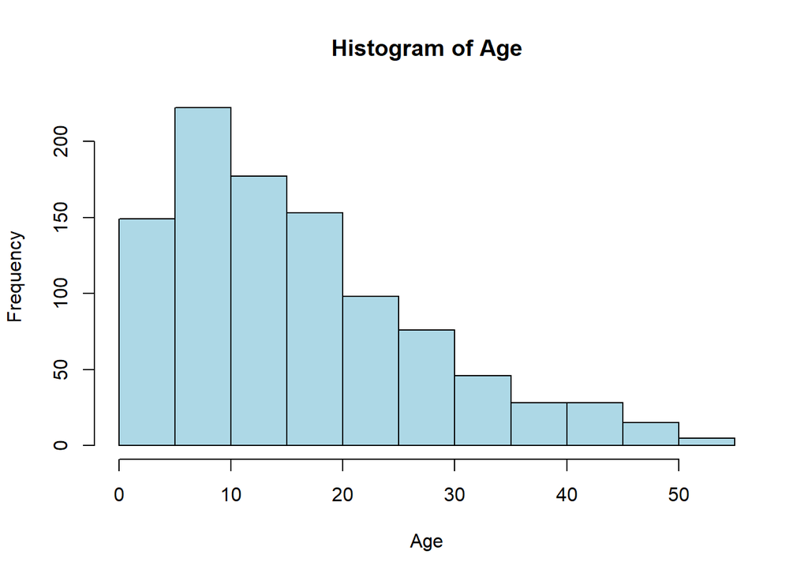

```r
hist(dataset$age, main = "Histogram of Age", xlab = "Age", ylab = "Frequency", col = "lightblue")
```

We ceated a histogram for the “Age” variable to show the age groups for our sample of customers to give a better understanding for our overall variables values and results.

```r
library(ggplot2)
```

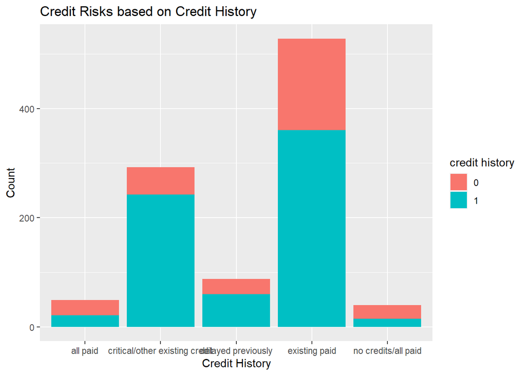

```r
ggplot(data = dataset, aes(x = credit_history, fill = class)) +
     geom_bar(position = "stack") +
     labs(title = "Credit Risks based on Credit History",
          x = "Credit History",
          y = "Count" ,
   fill = "credit history" )
```

The bar chart shows the distribution of credit history categories and how they are associated with good and bad credit risks, we used our class label which is the “class” attribute, to learn and understand how the credit history affects the decision when deciding a good or a bad credit risks for a customer.

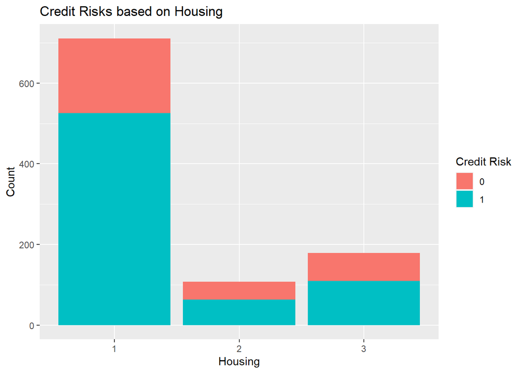

```r
ggplot(dataset, aes(x = housing, fill = class)) +
    geom_bar() +
      labs(
          x = "Housing",
          y = "Count",
          title = "Credit Risks based on Housing",
          fill = "Credit Risk"
      )
```

This bar chart shows what kind of credit risk customers have based on their housing, we noticed that a big percentage of “for free” type of housing have a bad credit, but to assist that we decided to define functions that will help us determine if our analysis to the chart was correct.

```r
forfree_bad_count <- nrow (subset(dataset,housing == "for free" & class == "bad"))
```

using this function, we discovered that more than 40% of customers who live in their houses for free have bad credits.

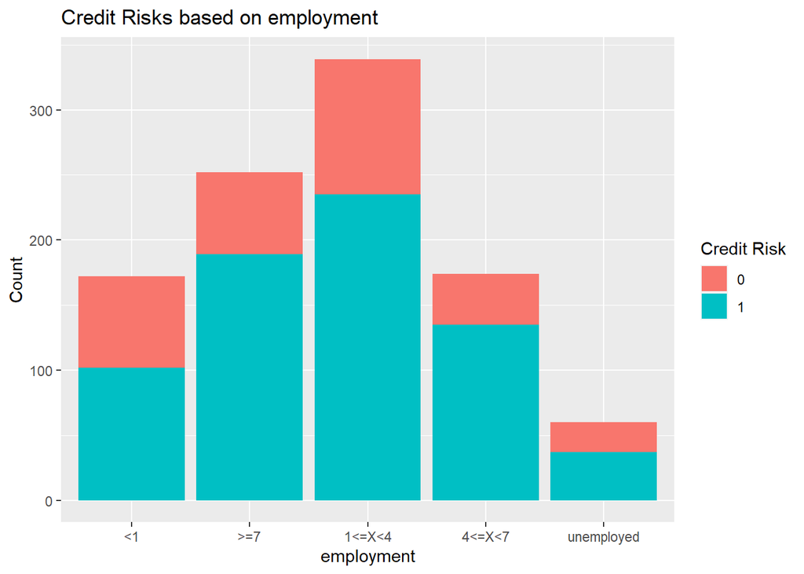

```r
ggplot(dataset, aes(x = employment, fill = class)) +
   geom_bar() +
     labs(
         x = "employment",
         y = "Count",
         title = "Credit Risks based on employment",
         fill = "Credit Risk"
     )
```

From this bar chart we found out that trying to find out whether a customer has a bad credit or a good one is difficult to determine based on their employment status only

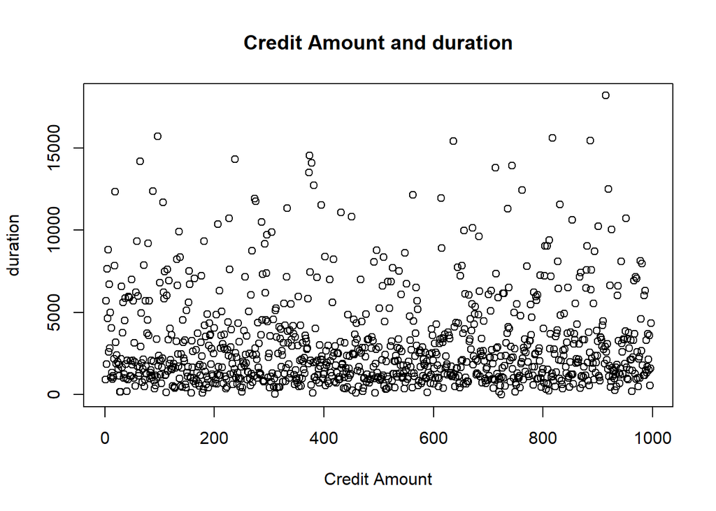

```r
plot(dataset$credit_amount, dataset$installment_duration,
     xlab = "Credit Amount", ylab = "duration",
     main = "Credit Amount and duration")
```

## Feature Selection :

Insuring that caret package is installed on install it :

```r
if (!require(caret)) {
  install.packages("caret")
}
library(caret)
```

Choosing the feature matrix (X) and target variable (Y) :

```r
X <- dataset[, c("credit_history", "savings_status", "employment")]
y <- dataset$class
```

Defining the number of cross-validation folds :

```r
CV_folds <- 10
train_control <- trainControl(method = "cv", number = CV_folds)
```

Use glm method :

```r
method <- "glm"
model <- train(X, y, method = method, trControl = train_control, metric = "AUC")
selected_features <- varImp(model)
print(selected_features)
```

```
## glm variable importance
##
##                                               Overall
## credit_historycritical/other existing credit 100.0000
## savings_statusno known savings                75.0771
## credit_historyexisting paid                   64.8129
## credit_historydelayed previously              52.2700
## employment4<=X<7                              50.3248
## savings_status500<=X<1000                     49.6206
## savings_status>=1000                          48.1684
## employment>=7                                 31.7044
## employment1<=X<4                              29.3471
## savings_status100<=X<500                      15.5923
## credit_historyno credits/all paid              0.7172
## employmentunemployed                           0.0000
```